# Discrete Time & Continious Time Event History Analysis

Sergej Kaiser

3/05/2017

The document shows some of the visualizations, which I created for the course ‘Event history analysis’. The focus of event history anlysis is to predict the time-to-event outcomes, such as e.g. birth of a child.  
The first visualizations show the discrete time analysis of the chance of a third birth. The continious time analysis is about general mortality risk.

### Discrete Time models

The first visualization displays the (lack of) fit of various specifications of the baseline hazard of the chance of a third birth.  
We model the chance of the third birth using a logistic regression. For each model the outcome is the birth of a third child and the dependent variable is time (const linear, quadratic, etc.).

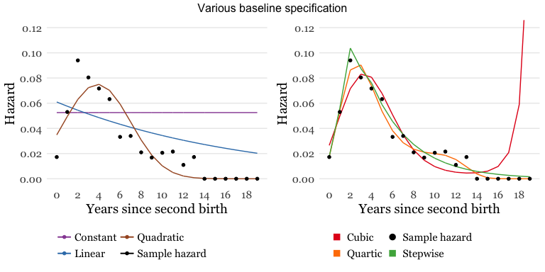

## Continious Event History

### Kaplan Meier cumulative hazard

The Kaplan-Meier estimator is a simple non-parametric method to obtain an estimate of the survival curve from time-to-event data. It can be used with both discrete and continious time-to-event data. Here our focus is to model the outcome general mortality by educational categories.

#### Kaplan-Meier with covariate education

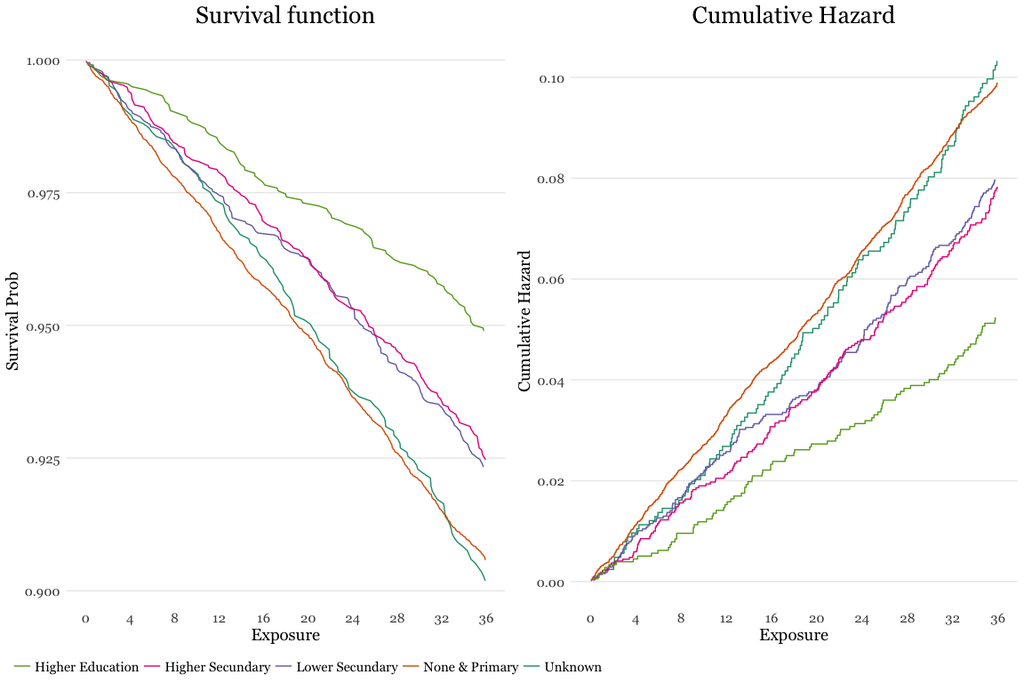